# ACM

## R Markdown

```r
data=read.csv("../Data/socsupport.csv",header=TRUE,sep=";")
attach(data)
str(data)
```

```
## 'data.frame':    95 obs. of  21 variables:
##  $ X           : int  1 2 3 4 5 6 7 8 9 10 ...
##  $ gender      : Factor w/ 2 levels "female","male": 2 1 2 2 1 1 1 1 1 2 ...
##  $ age         : Factor w/ 5 levels "18-20","21-24",..: 2 2 2 1 2 2 3 3 1 5 ...
##  $ country     : Factor w/ 2 levels "australia","other": 1 1 1 1 1 1 1 1 1 1 ...
##  $ marital     : Factor w/ 3 levels "married","other",..: 2 3 3 3 3 3 1 1 3 2 ...
##  $ livewith    : Factor w/ 6 levels "alone","friends",..: 5 5 6 4 2 2 5 5 4 1 ...
##  $ employment  : Factor w/ 5 levels "employed fulltime",..: 2 5 2 2 2 3 2 2 2 2 ...
##  $ firstyr     : Factor w/ 2 levels "first year","other": 2 2 2 1 2 2 2 2 2 2 ...
##  $ enrolment   : Factor w/ 3 levels "","full-time",..: 2 2 2 2 2 2 2 3 2 2 ...
##  $ emotional   : int  22 21 21 19 16 20 20 20 24 13 ...
##  $ emotionalsat: int  23 20 18 19 19 17 23 20 25 18 ...
##  $ tangible    : int  17 12 16 20 11 16 20 16 20 6 ...
##  $ tangiblesat : int  18 10 16 17 15 15 20 16 20 14 ...
##  $ affect      : int  15 10 15 11 6 12 14 12 15 6 ...
##  $ affectsat   : int  15 6 15 11 10 14 15 12 15 12 ...
##  $ psi         : int  12 9 13 13 11 12 15 12 12 6 ...
##  $ psisat      : int  13 6 12 12 12 11 15 12 15 11 ...
##  $ esupport    : int  13 12 14 15 9 13 15 13 16 10 ...
##  $ psupport    : int  11 7 13 15 7 12 10 11 NA 8 ...
##  $ supsources  : int  13 10 14 15 9 13 13 11 NA 9 ...
##  $ BDI         : int  5 8 16 0 9 0 1 14 12 20 ...
```

L’ACM s’effectue sur des variables qualitatives. Nous gardons seulement ces dernières.

```r
dataqual = data[,-c(1,10,11,12,13,14,15,16,17,18,19,20,21)]
dataqual
```

```
##    gender   age   country marital   livewith         employment    firstyr
## 1    male 21-24 australia   other    partner employed part-time      other
## 2  female 21-24 australia  single    partner   parental support      other
## 3    male 21-24 australia  single residences employed part-time      other
## 4    male 18-20 australia  single    parents employed part-time first year
## 5  female 21-24 australia  single    friends employed part-time      other
## 6  female 21-24 australia  single    friends    govt assistance      other
## 7  female 25-30 australia married    partner employed part-time      other
## 8  female 25-30 australia married    partner employed part-time      other
## 9  female 18-20 australia  single    parents employed part-time      other
## 10   male   40+ australia   other      alone employed part-time      other
## 11 female 21-24 australia  single    parents employed part-time      other
## 12 female 18-20 australia  single residences employed part-time      other
## 13 female 21-24 australia  single      other employed part-time      other
## 14 female 18-20 australia  single residences    govt assistance      other
```

[output cut: 177 more lines]

On applique l’ACM sur ce jeu de données :

```r
library("FactoMineR")

acm=MCA(dataqual)
```

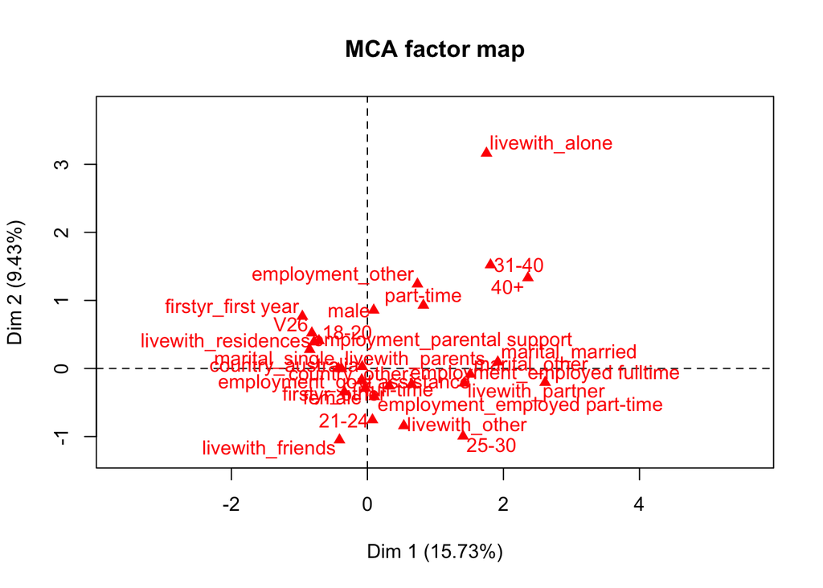

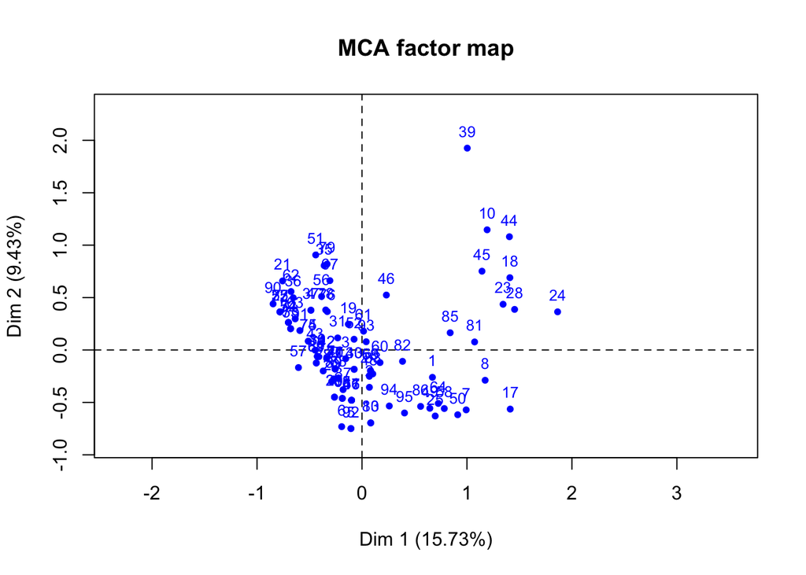

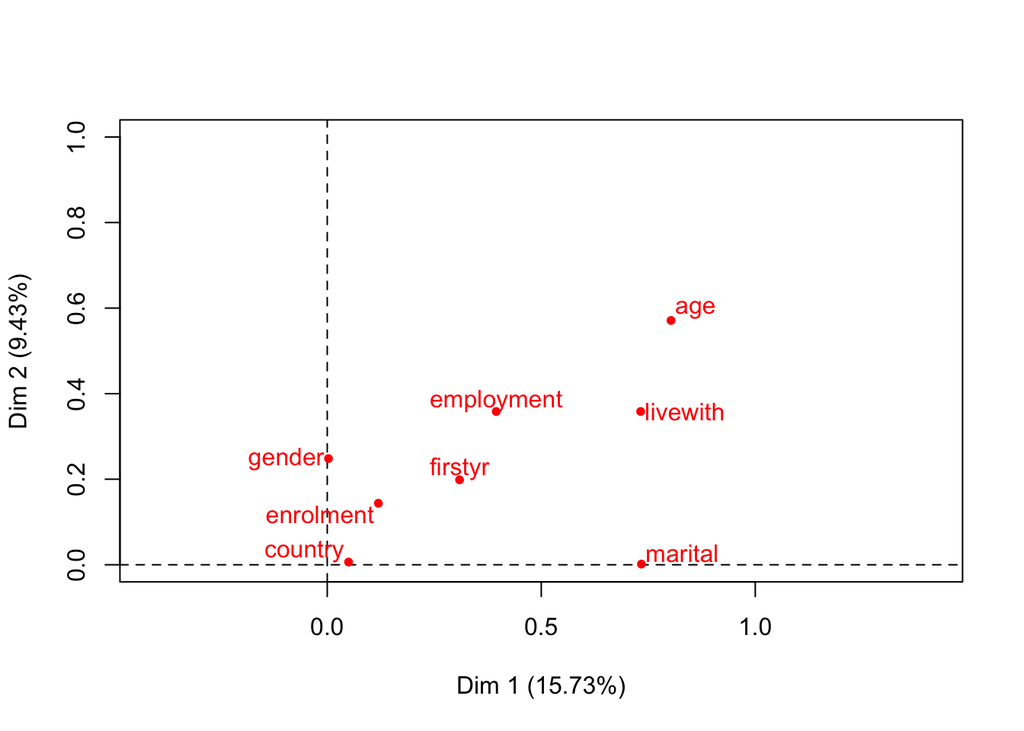

En ACM, le maximum d’inertie apporté par chaque axe est en général faible, nous allons donc conserver les axes avec une inertie supérieur à 1/8 (0.125).

```r
summary(acm)
```

```
##
## Call:
## MCA(X = dataqual)
##
##
## Eigenvalues
##                        Dim.1   Dim.2   Dim.3   Dim.4   Dim.5   Dim.6
## Variance               0.393   0.236   0.211   0.183   0.173   0.150
## % of var.             15.728   9.432   8.421   7.303   6.937   5.985
## Cumulative % of var.  15.728  25.160  33.581  40.883  47.821  53.806
##                        Dim.7   Dim.8   Dim.9  Dim.10  Dim.11  Dim.12
## Variance               0.148   0.133   0.125   0.107   0.099   0.088
## % of var.              5.901   5.306   5.015   4.298   3.970   3.524
## Cumulative % of var.  59.708  65.013  70.028  74.326  78.296  81.821
##                       Dim.13  Dim.14  Dim.15  Dim.16  Dim.17  Dim.18
## Variance               0.084   0.082   0.077   0.069   0.054   0.044
## % of var.              3.350   3.295   3.092   2.779   2.160   1.761
## Cumulative % of var.  85.171  88.466  91.558  94.337  96.497  98.258
##                       Dim.19  Dim.20
## Variance               0.029   0.014
## % of var.              1.179   0.563
## Cumulative % of var.  99.437 100.000
##
## Individuals (the 10 first)
##                      Dim.1    ctr   cos2    Dim.2    ctr   cos2    Dim.3
## 1                 |  0.671  1.206  0.195 | -0.261  0.304  0.029 | -0.468
## 2                 |  0.071  0.013  0.004 | -0.356  0.565  0.097 |  0.158
## 3                 | -0.155  0.065  0.019 | -0.083  0.031  0.005 | -0.373
## 4                 | -0.486  0.634  0.188 |  0.379  0.643  0.114 | -0.239
## 5                 | -0.105  0.030  0.005 | -0.749  2.505  0.270 | -0.403
## 6                 | -0.193  0.100  0.014 | -0.731  2.387  0.201 | -0.124
## 7                 |  0.993  2.638  0.263 | -0.571  1.456  0.087 |  0.626
## 8                 |  1.173  3.686  0.300 | -0.289  0.372  0.018 |  0.608
## 9                 | -0.256  0.176  0.109 | -0.180  0.144  0.054 | -0.147
## 10                |  1.192  3.805  0.138 |  1.147  5.868  0.127 | -0.858
##                      ctr   cos2
## 1                  1.094  0.095 |
## 2                  0.125  0.019 |
## 3                  0.697  0.109 |
## 4                  0.286  0.045 |
```

[output cut: 26 more lines]

```
## 40+                2.708 |  1.026  2.632  0.046  2.086 |
## country_australia  0.771 | -0.079  0.331  0.053 -2.230 |
## country_other     -0.771 |  0.670  2.810  0.053  2.230 |
## marital_married    0.300 |  1.173  7.746  0.144  3.681 |
##
## Categorical variables (eta2)
##                     Dim.1 Dim.2 Dim.3
## gender            | 0.003 0.248 0.189 |
## age               | 0.803 0.571 0.303 |
## country           | 0.050 0.006 0.053 |
## marital           | 0.734 0.002 0.151 |
## livewith          | 0.732 0.358 0.512 |
## employment        | 0.395 0.358 0.392 |
## firstyr           | 0.309 0.199 0.083 |
## enrolment         | 0.119 0.144 0.001 |
```

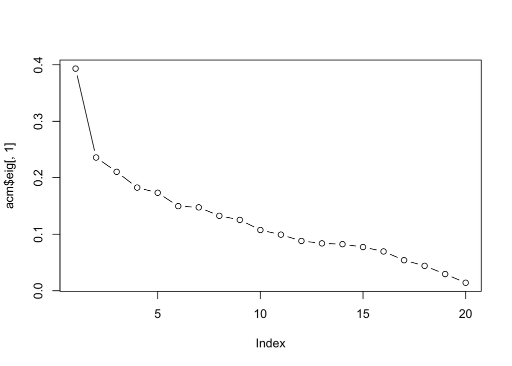

```r
plot(acm$eig[,1],type='b')
```

Il nous faudrait conserver 9 axes pour avoir une information suffisante.

Pour notre étude, nous allons nous contenter d’étudier les deux premiers axes qui fournissent tout de même 25% des informations sur le jeu de données

```r
acm$var$eta2
```

```
##                  Dim 1       Dim 2       Dim 3      Dim 4       Dim 5
## gender     0.002903156 0.248306591 0.189157526 0.02131524 0.025948722
## age        0.803191415 0.571104005 0.303289300 0.30210821 0.164950359
## country    0.049850433 0.006327966 0.052887910 0.33166521 0.022051704
## marital    0.734021591 0.001626402 0.150771698 0.26347192 0.019163208
## livewith   0.732241949 0.358335983 0.512138200 0.06660282 0.364599303
## employment 0.394819435 0.358206628 0.392274725 0.37787998 0.385881328
## firstyr    0.309114520 0.198604747 0.082508259 0.03352699 0.008358825
## enrolment  0.119438345 0.143811839 0.001199029 0.06394544 0.396534806
```

L’axe 1 est influencé par l’age, marital et livewith. L’axe 2 est influencé par l’age, livewith et employment.

Il semble apparaître une corrélation entre age, livewith, employment et marital aux vues des contribueurs de chaque axe.

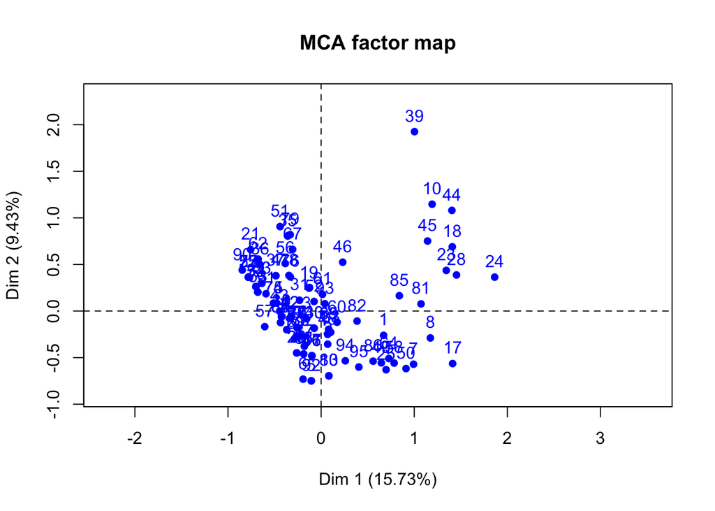

```r
plot(acm,invisible="var")
```

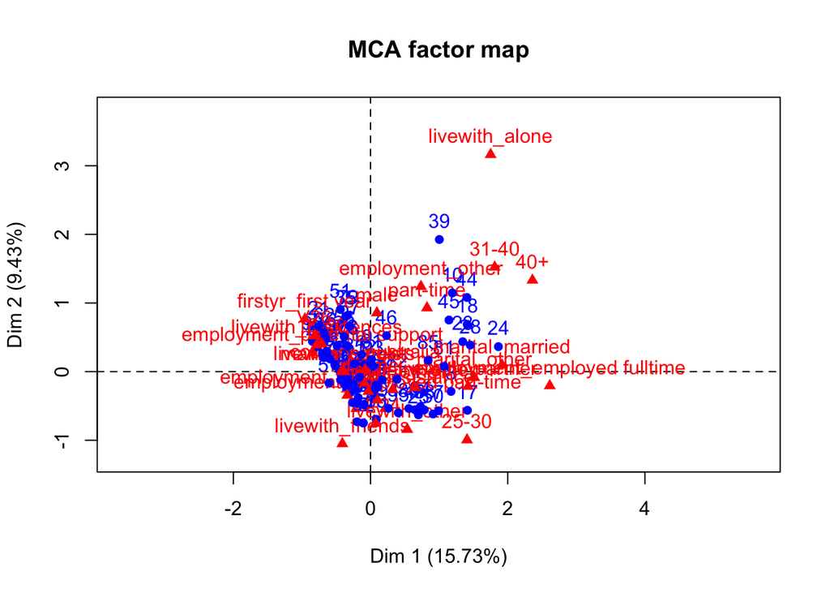

```r
plot(acm,invisible="quali.sup")
plot(acm)
```

Ici, comme dans l’ACP que nous avons effectué plus tôt, on retrouve deux groupes : un groupe avec la majeur partie des individus autour de l’origine (qu’on appelera premier groupe) et un groupe d’un peu moins de 10 individus sur le premier quadrant du plan (qu’on appelera deuxième groupe). On pourait tracer une droite d’équation y = 1.5-x pour les séparer. Nous allons observer les individus de ces groupes :

```r
dataqual[c(39,10,44,45,23,28,18,24),]
```

```
##    gender   age   country marital livewith         employment firstyr
## 39   male 31-40 australia  single    alone              other   other
## 10   male   40+ australia   other    alone employed part-time   other
## 44   male 31-40 australia married  partner              other   other
## 45   male 31-40 australia   other  partner              other   other
## 23 female 31-40     other married  partner              other   other
## 28 female   40+     other married  partner              other   other
## 18 female   40+ australia   other  partner              other   other
## 24 female   40+ australia married  partner  employed fulltime   other
##    enrolment
## 39 part-time
## 10 full-time
## 44 part-time
## 45 full-time
## 23 full-time
## 28 full-time
## 18 part-time
## 24 part-time
```

```r
dataqual[c(1,2,3,4,5,6,7,8,9,11,12,13,14,15),]
```

```
##    gender   age   country marital   livewith         employment    firstyr
## 1    male 21-24 australia   other    partner employed part-time      other
## 2  female 21-24 australia  single    partner   parental support      other
## 3    male 21-24 australia  single residences employed part-time      other
## 4    male 18-20 australia  single    parents employed part-time first year
## 5  female 21-24 australia  single    friends employed part-time      other
## 6  female 21-24 australia  single    friends    govt assistance      other
## 7  female 25-30 australia married    partner employed part-time      other
## 8  female 25-30 australia married    partner employed part-time      other
## 9  female 18-20 australia  single    parents employed part-time      other
## 11 female 21-24 australia  single    parents employed part-time      other
## 12 female 18-20 australia  single residences employed part-time      other
## 13 female 21-24 australia  single      other employed part-time      other
## 14 female 18-20 australia  single residences    govt assistance      other
## 15 female 21-24 australia  single    parents    govt assistance      other
##    enrolment
## 1  full-time
## 2  full-time
## 3  full-time
## 4  full-time
## 5  full-time
## 6  full-time
## 7  full-time
## 8  part-time
## 9  full-time
## 11 full-time
## 12 full-time
## 13 full-time
## 14 full-time
## 15 full-time
```

On remarque également un effet Guttman sur le graphique des individus. L’axe principal d’un effet Guttman oppose les extrêmes des données. Ici, on peut considérer que la population est scindable en deux populations “extrêmes” décrites dans les paragraphes précédents.

Nous allons afficher les individus en essayant de les regrouper par rapport aux différentes variables qualitatives.

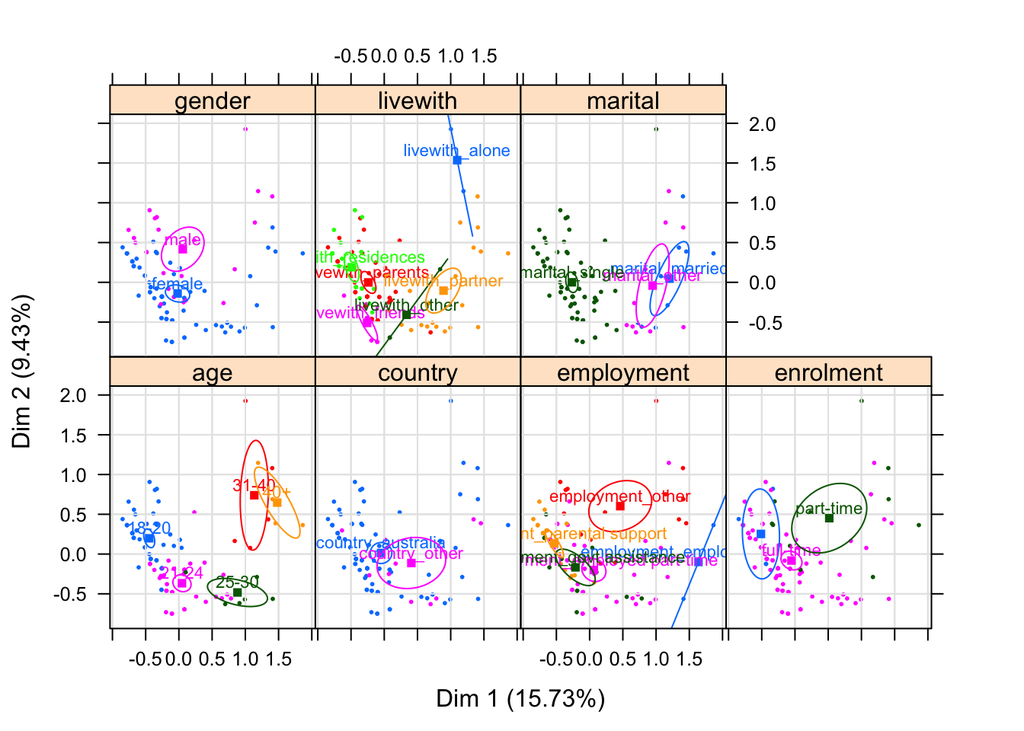

```r
plotellipses(acm, keepvar = c("marital","livewith","age","employment","enrolment","gender","country"),cex=0.7)
```

Si on superpose les graphiques liés à livewith, marital et age, on peut remarquer que les personnes de plus de 31 ans ont plus tendance soit à vivre seul ou avec un(e) partenaire et à être marié ou dans une autre situation. Les individus entre 18 et 20 ans sont en général célibataire et vivent avec des amis, en résidence, leur parent ou autre. Il n’y a pas d’autres corrélations apparentes entre les variables qualitatives. On en conclut une relation entre l’age, la situation amoureuse et les personnes avec qui l’individu vit.

Nous avons également dit, après l’observation des graphiques, qu’il serait éventuellement possible de séparer ces individus en deux groupes ce que nous avions également fait lors de l’ACP. Il serait intéressant de voir si ces groupes sont composés des mêmes individus. Nous allons par la suite utiliser les méthodes de classifications pour justement étudier cette fois les relations entre variables quantitatives et qualitatives.